# AV-BV analysis Runs 1 and 2

Sander Wuyts

19 November, 2018

# Introduction

Analysis of the AV BV data from Runs 1 and 2 (V4 region). Prior to this analysis, the samples were processed using the DADA2 software.

**Note**: Due to the fact that samplenames were renamed when uploading to ENA, one will not be able to rerun this analysis ‘out of the box’. This script will probably need several adaptions to conform with these new samplenames. Therefore, this analysis is uploaded more as guideline or an in depth methods section and not as an out of the box reproducible analysis. In the future, I will avoid this and try to create a reproducible script from the beginning of the project. Apologies!

The data for this study is derived from 3 different runs:

- A first run on 07 06 2017 - V4 region
- A second run on 21 08 2017 - V4 region
- A third run on xxx - V1V2 region

Only the two first runs were analysed here in this script.

# Setup and themes

```r
#### Theme for publication: http://areshenk-research-notes.com/publication-quality-plots-in-r/ ####

theme_pub <- function (base_size = 12, base_family = "") {
  theme_grey(base_size = base_size,
             base_family = base_family) %+replace%

    theme(# Set text size
      plot.title = element_text(size = 18),
      axis.title.x = element_text(size = 16),
      axis.title.y = element_text(size = 16,
                                  angle = 90),
      axis.text.x = element_text(size = 14,colour="black",element_text(margin = margin(5,0,0,0),
                                                                       angle = 90)),
      axis.text.y = element_text(size = 14,colour="black",element_text(margin = margin(0,5,0,0))),
      strip.text.y = element_text(size = 15,
                                  angle = -90),

      # Legend text
      legend.title = element_text(size = 15),
      legend.text = element_text(size = 15),
      legend.background = element_rect(fill = "transparent", colour=NA),

      # Configure lines and axes
      axis.ticks.x = element_line(colour = "black"),
      axis.ticks.y = element_line(colour = "black"),

      # Plot background
      panel.background = element_rect(fill = "transparent",colour=NA),
      panel.grid.major = element_blank(),
      panel.grid.minor = element_blank(),
      plot.background = element_rect(fill="transparent", colour=NA),

      # Facet labels
      legend.key = element_blank(),
      strip.background = element_rect(fill = "transparent",
                                      colour = NA,
                                      size = 0.1),
       panel.border = element_rect(colour = "black", fill="transparent"),
       strip.text.x = element_text(size=18,face="bold",margin=margin(0,0,5,0))
      )

}

# Create colour palette for taxonomy plotting

colours <- c("#a6cee3","#1f78b4","#b2df8a","#33a02c","#fb9a99",
             "#e31a1c","#fdbf6f","#ff7f00","#cab2d6","#6a3d9a",
             "#ffff99","#b15928","#8BC395","#919D5F","#EB494A",
             "#F79C5D","#DEB969")

# Other useful function

library(stringr)
name_otus = function(ps) {

  otuName = as.character(tax_table(ps)[,"genus"])
  otuName = str_split_fixed(otuName, "\\(", 2)[,1]
  names(otuName) = taxa_names(ps)

  for (level in c("family", "order", "class", "phylum","kingdom")) {
    uncl = (otuName=="")
    if (!any(uncl)) break
    otuName[uncl] = as.character(tax_table(ps)[uncl,level])
    otuName[uncl] = str_split_fixed(otuName[uncl], "\\(", 2)[,1]
  }

  otuName = sub("_[1-9]$", "", otuName) # remove appendices like "_1"
  otuName = factor(otuName, unique(otuName))
  otuName = otuName[order(otuName)]

# Uncomment these lines if you want indices behind name
  # index = unlist(tapply(names(otuName), otuName, function(x)
  #  if (length(x)==1) return("") else return(as.character(1:length(x)))
  #))
  #otuNameFull = paste(otuName, index, sep=" ")
  #otuNameFull = sub(" $", "", otuNameFull)
  #names(otuNameFull) = names(otuName)
  #return(otuNameFull)

  return(otuName)
}


# Create distance matrix and reformat for easy plotting
calculateDistMat <- function(phylo_obj){
  # Calculate distance matrix
  dm <- vegdist(otu_table(phylo_obj), method="bray")

  # Reformat the  to long format matrix
  m <- data.frame(t(combn(rownames(otu_table(phylo_obj)),2)), as.numeric(dm))
  names(m) <- c("sample1", "sample2", "distance")

  # Add condition
  m$condition_sample1 <- str_split_fixed(m$sample1,"_",4)[,1]
  m$condition_sample2 <- str_split_fixed(m$sample2,"_",4)[,1]

  # Add condition
  m$patient_sample1 <- str_split_fixed(m$sample1,"_",4)[,2]
  m$patient_sample2 <- str_split_fixed(m$sample2,"_",4)[,2]


  return(m)
}
```

# Read in dataframe

These objects were created during DADA2 analysis

```r
library(phyloseq)
library(vegan)
library(tidyverse)
```

```r
library(ggpubr) # For merging images
library(ggrepel) # To avoid overlapping of labels on some plots

# Load dfs from run1
load('taxonTable.Robject')
load('seqTable.nochim.fil.Robject')
colnames(taxonTable) <- str_to_lower(colnames(taxonTable))

# Merge into phyloseq object
ps <- phyloseq(otu_table(as.matrix(seqTable.nochim.fil), taxa_are_rows=FALSE),
               tax_table(as.matrix(taxonTable)),
               sample_data(data.frame(
                 description = rep(NA, length(row.names(seqTable.nochim.fil))),
                 run = rep('Run1', length(row.names(seqTable.nochim.fil))),
                 row.names = row.names(seqTable.nochim.fil)
               )))


# Load data from run 2
load('Eline_newdata.Robject')

# Rename samples from second run
sample_names(Eline) <- str_sub(sample_data(Eline)$description,3,-1)

# merge both phyloseq objects
ps <- merge_phyloseq(ps, Eline)

ps
```

```
## phyloseq-class experiment-level object
## otu_table()   OTU Table:         [ 383 taxa and 171 samples ]
## sample_data() Sample Data:       [ 171 samples by 2 sample variables ]
## tax_table()   Taxonomy Table:    [ 383 taxa by 7 taxonomic ranks ]
```

This means we found 383 different taxa in this study. Let’s have a sneak peak at the first 10 of genusnames of these taxa:

```r
as.character(tax_table(ps)[1:10,6])
```

```
##  [1] "Lactobacillus" "Lactobacillus" "Gardnerella"   "Gardnerella"
##  [5] "Lactobacillus" "Sneathia"      "Prevotella"    "Prevotella"
##  [9] "Atopobium"     "Lactobacillus"
```

Add metadata, which we just derive from the sample names.

```r
condition <- substring(sample_names(ps),1,2)
patient <- substring(sample_names(ps),3,4)

metadata_Eline <- data.frame(sample_names(ps),condition,patient)
metadata_Eline$patient <- as.character(metadata_Eline$patient)
names(metadata_Eline)[1] <- "sample"
```

There are 5 samples marked as “ns” (not sure) because at the time of sequencing we did not have the right patient information. We do now, so let’s rename them. Ns1, ns2, ns3 and ns5 are BV18-BV21, while ns4 is NL20. Let’s adapt that here:

```r
rownames(metadata_Eline) <- metadata_Eline$sample

# Change ns1-ns5
metadata_Eline$condition[c(145:150,153:154)] <- "BV"
metadata_Eline$patient[c(145:150,153:154)] <- c(18,18,19,19,20,20,21,21)

# Change ns4
metadata_Eline$condition[151:152] <- "NL"
metadata_Eline$patient[151:152] <- "20"


sample_data(ps)  <- sample_data(metadata_Eline)
ps_Eline <- ps
ps_Eline
```

```
## phyloseq-class experiment-level object
## otu_table()   OTU Table:         [ 383 taxa and 171 samples ]
## sample_data() Sample Data:       [ 171 samples by 3 sample variables ]
## tax_table()   Taxonomy Table:    [ 383 taxa by 7 taxonomic ranks ]
```

Merge technical repeats

```r
grouping_factor = apply(sample_data(ps_Eline)[,c(2:3)], 1, paste0,collapse="_")
psM = merge_samples(ps_Eline, group=grouping_factor)
psM.sample_data = str_split_fixed(rownames(sample_data(psM)), pattern="_", n=ncol(sample_data(psM))-1)
rownames(psM.sample_data) = rownames(sample_data(psM))
colnames(psM.sample_data) = colnames(sample_data(psM))[2:ncol(sample_data(psM))]
psM.sample_data = data.frame(psM.sample_data)
sample_data(psM) = sample_data(psM.sample_data)

ps_Eline <- psM
ps_Eline
```

```
## phyloseq-class experiment-level object
## otu_table()   OTU Table:         [ 383 taxa and 82 samples ]
## sample_data() Sample Data:       [ 82 samples by 2 sample variables ]
## tax_table()   Taxonomy Table:    [ 383 taxa by 7 taxonomic ranks ]
```

Remove samples that that we won’t include in this study:

```r
# Remove CA (samples were not part of this study)
samples_to_keep <- !sample_data(ps_Eline)$condition=="CA"
ps_Eline <- prune_samples(samples_to_keep,ps_Eline)

# Remove BV03, BV04 and NL08, NL09, AV18, AV15, AV14, AV07
samples_to_keep <- !row.names(sample_data(ps_Eline))%in%c("BV_03","BV_04","NL_08","NL_09","AV_01", "AV_11", "AV_18", "AV_15", "AV_14", "AV_07")
ps_Eline <- prune_samples(samples_to_keep,ps_Eline)

# Remove the ones without condition
samples_to_keep <- !sample_data(ps_Eline)$condition %in% c("15", "16", "36")
ps_Eline <- prune_samples(samples_to_keep,ps_Eline)

# Remove empty taxa
ps_Eline <- prune_taxa(taxa_sums(ps_Eline) > 0, ps_Eline)

ps_Eline
```

```
## phyloseq-class experiment-level object
## otu_table()   OTU Table:         [ 333 taxa and 57 samples ]
## sample_data() Sample Data:       [ 57 samples by 2 sample variables ]
## tax_table()   Taxonomy Table:    [ 333 taxa by 7 taxonomic ranks ]
```

# Alpha diversity

```r
# Calculate richness
richness <- estimate_richness(ps_Eline,measures=c('Observed','Shannon'))
richness$Samplename <- row.names(richness)

# Melt/gather
richness <- richness %>%
  gather(.,key="DivType",value="Alphadiv", Observed, Shannon)

# Add rest of metadata
metadata <- as.data.frame(as.matrix(sample_data(ps_Eline)))
metadata$Samplename <- row.names(metadata)

# merge
richness <- merge.data.frame(richness,metadata,all.x=T,by= "Samplename")

# Convert divtype to factor
richness$DivType <- factor(richness$DivType,levels=c("Observed","Shannon"))
```

Plot alpha diversity

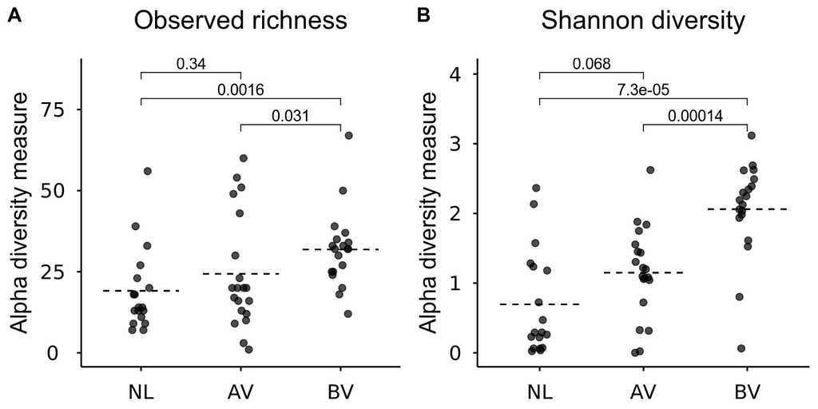

```r
comparisons <- list(c("AV", "BV"), c("BV", "NL"), c("AV", "NL"))

# Obseverd richness
observed <- richness %>%
  filter(!is.na(condition)) %>%
  filter(DivType  == "Observed") %>%
  mutate(condition = fct_relevel(condition, "NL", "AV", "BV")) %>%
  ggplot(aes(x=condition, y=Alphadiv)) +
  geom_jitter(width = 0.09, height = 0, size=2, alpha= 0.7) +
  theme_pub() +
  expand_limits(y=0) +
  stat_summary(fun.y = mean, geom = "errorbar", aes(ymax = ..y.., ymin = ..y.. ),
                 width = .76, linetype = "dashed")  +
  stat_compare_means(aes(label = ..p.adj..), comparisons = comparisons, p.adjust.method = "holm", paired = F) +
  theme(axis.title.x = element_blank(),
        axis.text.x = element_text(margin = margin(8,0,0,0)),
        axis.title.y = element_text(margin = margin(0,8,0,0)),
        axis.text.y = element_text(margin = margin(0,8,0,0)),
        panel.border = element_blank(),
        axis.line = element_line(colour = "black")) +
  ggtitle("Observed richness\n") +
  ylab("Alpha diversity measure")

# Shannon diversity
shannon <- richness %>%
  filter(!is.na(condition)) %>%
  filter(DivType  == "Shannon") %>%
  mutate(condition = fct_relevel(condition, "NL", "AV", "BV")) %>%
  ggplot(aes(x=condition, y=Alphadiv)) +
  geom_jitter(width = 0.09, height = 0, size=2, alpha= 0.7) +
  theme_pub() +
  expand_limits(y=0) +
  stat_summary(fun.y = mean, geom = "errorbar", aes(ymax = ..y.., ymin = ..y.. ),
                 width = .76, linetype = "dashed")  +
  stat_compare_means(aes(label = ..p.adj..), comparisons = comparisons, p.adjust.method = "holm", paired = F) +
  theme(axis.title.x = element_blank(),
        axis.text.x = element_text(margin = margin(8,0,0,0)),
        axis.title.y = element_text(margin = margin(0,8,0,0)),
        axis.text.y = element_text(margin = margin(0,8,0,0)),
        panel.border = element_blank(),
        axis.line = element_line(colour = "black")) +
  ggtitle("Shannon diversity\n") +
  ylab("Alpha diversity measure")

# Arrange in one figure
ggarrange(observed, shannon,
          labels = c("A", "B"))
```

```r
ggsave("Figure1.svg", last_plot(), width = 17.8, height = 10, units = "cm")
```

Add some statistics. First from the Observed alphadiv estimator

```r
richness_shannon <- richness %>%
  filter(!is.na(condition)) %>%
  filter(DivType  == "Observed")

compare_means(Alphadiv ~ condition, p.adjust.method = "holm", data = richness_shannon)
```

```
## # A tibble: 3 x 8
##   .y.      group1 group2       p  p.adj p.format p.signif method
##   <chr>    <chr>  <chr>    <dbl>  <dbl> <chr>    <chr>    <chr>
## 1 Alphadiv AV     BV     0.0313  0.063  0.0313   *        Wilcoxon
## 2 Alphadiv AV     NL     0.341   0.34   0.3410   ns       Wilcoxon
## 3 Alphadiv BV     NL     0.00155 0.0047 0.0016   **       Wilcoxon
```

Now also from the Shannon alphadiv estimator

```r
richness_shannon <- richness %>%
  filter(!is.na(condition)) %>%
  filter(DivType  == "Shannon")

compare_means(Alphadiv ~ condition, p.adjust.method = "holm", data = richness_shannon)
```

```
## # A tibble: 3 x 8
##   .y.      group1 group2         p    p.adj p.format p.signif method
##   <chr>    <chr>  <chr>      <dbl>    <dbl> <chr>    <chr>    <chr>
## 1 Alphadiv AV     BV     0.000141  0.000280 0.00014  ***      Wilcoxon
## 2 Alphadiv AV     NL     0.0677    0.068    0.06767  ns       Wilcoxon
## 3 Alphadiv BV     NL     0.0000732 0.00022  7.3e-05  ****     Wilcoxon
```

Report the mean numbers of both estimators for all conditions.

```r
richness %>%
  filter(!is.na(condition)) %>%
  group_by(DivType, condition) %>%
  summarise(mean = mean(Alphadiv))
```

```
## # A tibble: 6 x 3
## # Groups:   DivType [?]
##   DivType  condition   mean
##   <fct>    <fct>      <dbl>
## 1 Observed AV        24.4
## 2 Observed BV        31.8
## 3 Observed NL        19.1
## 4 Shannon  AV         1.15
## 5 Shannon  BV         2.06
## 6 Shannon  NL         0.695
```

# Beta div

Perform PCoA and plot.

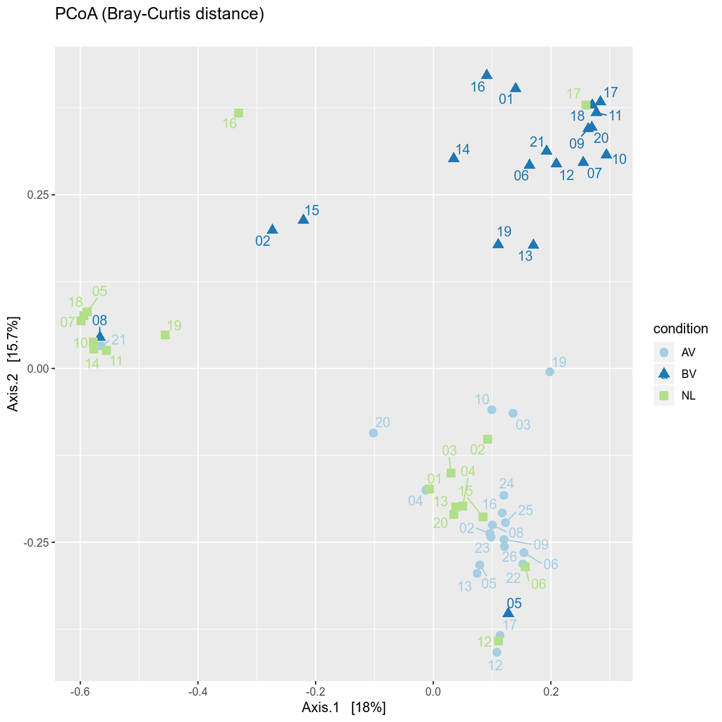

```r
# Beta div
title <- "PCoA (Bray-Curtis distance) \n"
ordination <- ordinate(ps_Eline,"PCoA","bray")
p <- plot_ordination(ps_Eline, ordination, color="condition", type = "samples", shape = "condition")
p <- p + geom_point(size=3) + ggtitle(title)
p + scale_color_manual(values=colours) +
  geom_text_repel(mapping= aes(label=patient))
```

Calculate relative abundance and merge taxa that are from the same genus.

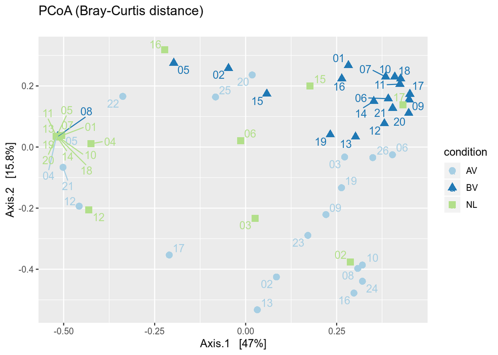

```r
# Calculate relative abundance
ps_Eline_relabun <- transform_sample_counts(ps_Eline,  function(OTU) OTU/sum(OTU))
ps_Eline_relabun_merged_genus <- tax_glom(ps_Eline_relabun, taxrank = 'genus')

title <- "PCoA (Bray-Curtis distance) \n"
ordination <- ordinate(ps_Eline_relabun_merged_genus,"PCoA","bray")
p <- plot_ordination(ps_Eline, ordination, color="condition", type = "samples", shape = "condition")
p <- p + geom_point(size=3) + ggtitle(title)
p + scale_color_manual(values=colours) +
  geom_text_repel(mapping= aes(label=patient))
```

Calculate a distance matrix and plot difference in Beta diversity.

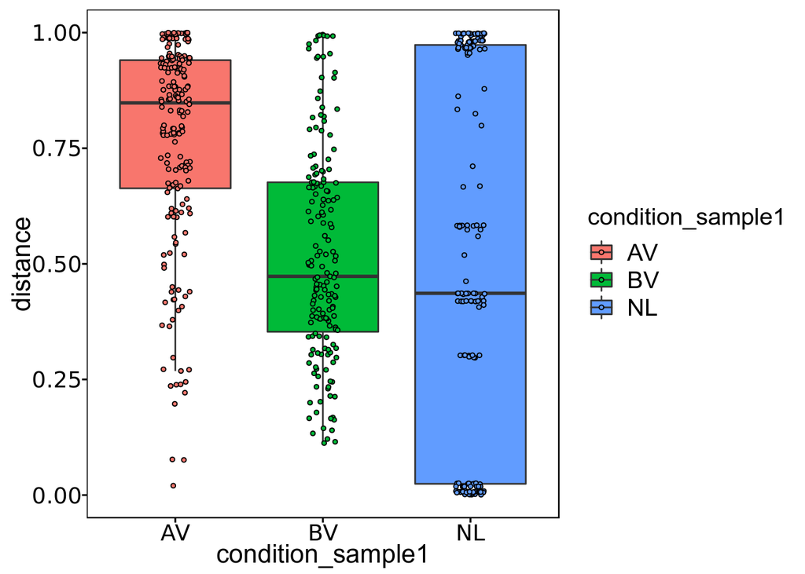

```r
calculateDistMat(ps_Eline_relabun_merged_genus) %>%
  filter(condition_sample1 == condition_sample2) %>%
  ggplot(aes(x=condition_sample1, fill=condition_sample1, y = distance)) +
  geom_boxplot(outlier.alpha = 0) +
  geom_jitter(aes(fill = condition_sample1),  shape = 21, size = 1, width = 0.1) +
  theme_pub()
```

# Taxonomic composition

Let’s plot the taxonomic composition of the TOP 20 ASVs.

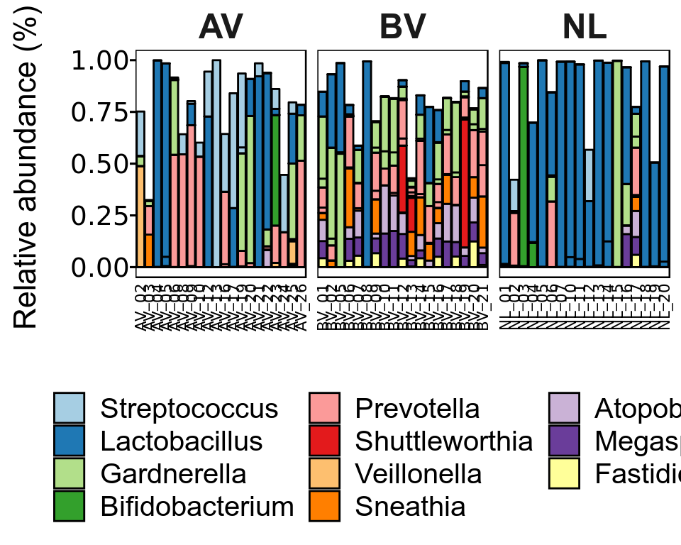

```r
# Taxonomic composition
# Calculate relative abundance
ps_Eline_relabun <- transform_sample_counts(ps_Eline,  function(OTU) OTU/sum(OTU))

# Calculate top 20 OTUs
top20otus = names(sort(taxa_sums(ps_Eline_relabun), TRUE)[1:20])
ps_Eline_relabun_top20 = prune_taxa(top20otus, ps_Eline_relabun)

# Convert phyloseq object into large dataframe to be able to change the order of the stacking
ps_Eline_relabun_top20df <- psmelt(ps_Eline_relabun_top20)

# Add new column with highest unclassified taxonomic rank
highest_unclassified_rank <- name_otus(ps_Eline_relabun_top20)
  # Convert to df
highest_unclassified_rankdf <- cbind(read.table(text=names(highest_unclassified_rank)),highest_unclassified_rank)
  # Merge
ps_Eline_relabun_top20df <- merge(ps_Eline_relabun_top20df,highest_unclassified_rankdf,by.x="OTU",by.y="V1")

# Relevel to get right order in legend
temp <- unique(ps_Eline_relabun_top20df[order(-ps_Eline_relabun_top20df$Abundance),"highest_unclassified_rank"])
ps_Eline_relabun_top20df$highest_unclassified_rank <- factor(ps_Eline_relabun_top20df$highest_unclassified_rank, levels=temp)

# Plot using ggplot2, colouring genus
ggplot(ps_Eline_relabun_top20df[order(ps_Eline_relabun_top20df$Abundance),], aes(x=Sample, y=Abundance, fill=highest_unclassified_rank)) + geom_bar(stat = "identity", color = "black") +
  ylab("Relative abundance (%) \n") +
  xlab("") +
  theme_pub() +
  theme(axis.text.x= element_text(size = 8,colour="black",angle=90),
        axis.ticks.x=element_blank(),
        legend.position="bottom") +
  labs(fill="") +
  scale_fill_manual(values = c(colours,"#FF0000","#000000","#FFFFFF")) +
  ylim(0,1.2) +
  scale_y_continuous(breaks=c(0,0.25,0.5,0.75,1))+
  guides(fill=guide_legend(byrow=F,ncol=3)) +
  facet_wrap(~condition,scales="free_x")
```

## AV Only

Prune AV samples only and replot:

```r
samples_to_keep <- sample_data(ps_Eline)$condition=="AV"
ps_Eline_AV  <- prune_samples(samples_to_keep,ps_Eline)
```

Add additional metadata: namely the AV scores.

```r
AV_scores <- readxl::read_excel("AVscores.xlsx") %>%
  filter(!is.na(Avscore)) %>%
  rename(Sample = sample) %>%
  mutate(Sample = as_factor(Sample)) %>%
  mutate(Sample = fct_reorder(Sample, Avscore))

scores <- AV_scores %>%
  ggplot(aes(x = Sample, y = Avscore)) +
  geom_col( fill = "black") +
  theme_pub() +
  scale_y_continuous() +
  theme(axis.ticks.x = element_blank(),
        axis.text.x = element_blank(),
        axis.text.y = element_text(size = 5, colour="black"),
        legend.position = "bottom",
        legend.text = element_text(size = 10),
        axis.title.y = element_text(size = 8),
        panel.background = element_rect(fill = "white"),
        panel.grid.major = element_blank(),
        panel.grid.minor = element_blank(),
        panel.border = element_rect(fill="transparent",color=NA),
        plot.title = element_blank(),
        plot.margin = margin(t = 0)) +
  scale_y_reverse(breaks = c(0, 5, 10)) +
  xlab('') +
  ylab("AV score")
```

Replot the taxonomic composition.

```r
# Taxonomic composition
# Calculate relative abundance
ps_Eline_AV_relabun <- transform_sample_counts(ps_Eline_AV,  function(OTU) OTU/sum(OTU))

# Calculate top 20 OTUs
top20otus = names(sort(taxa_sums(ps_Eline_AV_relabun), TRUE)[1:20])

# Create new df with highest unclassified rank
highest_unclassified_rank <- name_otus(ps_Eline_AV_relabun) %>%
  as.tibble() %>%
  rownames_to_column("OTU") %>%
  rename(highest_unclassified_rank = value) %>%
  filter(OTU %in% top20otus)

# Merge
ps_Eline_AV_relabundf <- psmelt(ps_Eline_AV_relabun) %>%
  left_join(highest_unclassified_rank) %>%
  mutate(highest_unclassified_rank = as.character(highest_unclassified_rank)) %>%
  replace_na(list(highest_unclassified_rank = "Residual"))
# Relevel sample factor in dataset to follow the clustering order
ps_Eline_AV_relabundf <- ps_Eline_AV_relabundf %>%
  left_join(AV_scores) %>%
  mutate(Sample = fct_reorder(Sample, Avscore))
```

```r
# Reorder the order of taxnames
topgenera_AV <- unique(highest_unclassified_rank$highest_unclassified_rank) %>%
  as.character() %>%
  c(., "Residual")
ps_Eline_AV_relabundf$highest_unclassified_rank <- factor(ps_Eline_AV_relabundf$highest_unclassified_rank, level = topgenera_AV)

# Plot using ggplot2
AV <- ggplot(ps_Eline_AV_relabundf, aes(x=Sample, y=Abundance, fill=highest_unclassified_rank)) +
  geom_bar(stat = "identity", color = "black", position = position_stack(reverse = T)) +
  ylab("Relative abundance (%)") +
  xlab("") +
  theme_pub() +
  theme(axis.text.y = element_text(size = 5, colour="black", margin = margin(0,1,0,0)),
        axis.ticks.x = element_blank(),
        axis.text.x = element_text(size = 5, colour="black", angle = 90, margin = margin(0,0,0,0)),
        legend.position="bottom",
        axis.title.y = element_text(size = 8),
        panel.border = element_blank(),
        plot.title = element_text(size = 8),
        legend.margin = margin(0,-10, 5, 0),
        legend.box.margin = margin(0,-10, 0 ,-10),
        legend.text = element_text(size = 6),
        legend.key.size = unit(6, "pt"),
        plot.margin = margin(b = 0, t = 5)) +
  labs(fill="") +
  scale_fill_manual(values = c(colours,"#FF0000","#000000","#FFFFFF")) +
  scale_y_continuous(breaks=c(0,0.25,0.5,0.75,1))+
  guides(fill=guide_legend(byrow=F, ncol=3)) +
  ggtitle("AV")
```

## BV Only

Now, let’s prune the BV samples ans study these seperatly.

```r
samples_to_keep <- sample_data(ps_Eline)$condition=="BV"
ps_Eline_BV  <- prune_samples(samples_to_keep,ps_Eline)
```

```r
# Taxonomic composition
# Calculate relative abundance
ps_Eline_BV_relabun <- transform_sample_counts(ps_Eline_BV,  function(OTU) OTU/sum(OTU))

# Calculate top 20 OTUs
top20otus = names(sort(taxa_sums(ps_Eline_BV_relabun), TRUE)[1:20])

# Create new df with highest unclassified rank
highest_unclassified_rank <- name_otus(ps_Eline_BV_relabun) %>%
  as.tibble() %>%
  rownames_to_column("OTU") %>%
  rename(highest_unclassified_rank = value) %>%
  filter(OTU %in% top20otus)

# Merge
ps_Eline_BV_relabundf <- psmelt(ps_Eline_BV_relabun) %>%
  left_join(highest_unclassified_rank) %>%
  mutate(highest_unclassified_rank = as.character(highest_unclassified_rank)) %>%
  replace_na(list(highest_unclassified_rank = "Residual"))
```

```r
# Cluster on similarity
clust <- otu_table(ps_Eline_BV_relabun) %>%
  vegdist(.,method = "bray") %>% # Calculate Bray-Curtis distance matrix
  hclust(method = "average") # Perform hierarchical clustering

clustOrder <- clust$labels[clust$order]

# Relevel sample factor in dataset to follow the clustering order
ps_Eline_BV_relabundf$Sample <- factor(ps_Eline_BV_relabundf$Sample, level = clustOrder)

# Reorder the order of taxnames
topgenera_BV <- unique(highest_unclassified_rank$highest_unclassified_rank) %>%
  as.character() %>%
  c(., "Residual")
ps_Eline_BV_relabundf$highest_unclassified_rank <- factor(ps_Eline_BV_relabundf$highest_unclassified_rank, level = topgenera_BV)

# Plot using ggplot2
BV <- ggplot(ps_Eline_BV_relabundf, aes(x=Sample, y=Abundance, fill=highest_unclassified_rank)) +
  geom_bar(stat = "identity", color = "black", position = position_stack(reverse = T)) +
  ylab("Relative abundance (%)") +
  xlab("") +
  theme_pub() +
  theme(axis.text.y = element_text(size = 5, colour="black", margin = margin(0,1,0,0)),
        axis.ticks.x = element_blank(),
        axis.text.x = element_text(size = 5, colour="black", angle = 90, margin = margin(0,0,0,0)),
        legend.position="bottom",
        axis.title.y = element_text(size = 8),
        panel.border = element_blank(),
        legend.margin = margin(-10, 5, 5, -10),
        legend.box.margin = margin(-10,0, 5 ,-10),
        legend.text = element_text(size = 5),
        legend.key.size = unit(4, "pt"),
        plot.title = element_text(size = 8)) +
  labs(fill="") +
  scale_fill_manual(values = c(colours,"#FF0000","#000000","#FFFFFF")) +
  scale_y_continuous(breaks=c(0,0.25,0.5,0.75,1))+
  guides(fill=guide_legend(byrow=F, ncol=3)) +
  ggtitle("BV")
```

## NL Only

Finally, repeat the analysis for the NL samples again.

```r
samples_to_keep <- sample_data(ps_Eline)$condition=="NL"
ps_Eline_NL  <- prune_samples(samples_to_keep,ps_Eline)
```

```r
# Taxonomic composition
# Calculate relative abundance
ps_Eline_NL_relabun <- transform_sample_counts(ps_Eline_NL,  function(OTU) OTU/sum(OTU))

# Calculate top 20 OTUs
top20otus = names(sort(taxa_sums(ps_Eline_NL_relabun), TRUE)[1:20])

# Create new df with highest unclassified rank
highest_unclassified_rank <- name_otus(ps_Eline_NL_relabun) %>%
  as.tibble() %>%
  rownames_to_column("OTU") %>%
  rename(highest_unclassified_rank = value) %>%
  filter(OTU %in% top20otus)

# Merge
ps_Eline_NL_relabundf <- psmelt(ps_Eline_NL_relabun) %>%
  left_join(highest_unclassified_rank) %>%
  mutate(highest_unclassified_rank = as.character(highest_unclassified_rank)) %>%
  replace_na(list(highest_unclassified_rank = "Residual"))
```

```r
# Cluster on similarity
clust <- otu_table(ps_Eline_NL_relabun) %>%
  vegdist(.,method = "bray") %>% # Calculate Bray-Curtis distance matrix
  hclust(method = "average") # Perform hierarchical clustering

clustOrder <- clust$labels[clust$order]

# Relevel sample factor in dataset to follow the clustering order
ps_Eline_NL_relabundf$Sample <- factor(ps_Eline_NL_relabundf$Sample, level = clustOrder)

# Reorder the order of taxnames
topgenera_NL <- unique(highest_unclassified_rank$highest_unclassified_rank) %>%
  as.character() %>%
  c(., "Residual")
ps_Eline_NL_relabundf$highest_unclassified_rank <- factor(ps_Eline_NL_relabundf$highest_unclassified_rank, level = topgenera_NL)

# Plot using ggplot2
NL <- ggplot(ps_Eline_NL_relabundf, aes(x=Sample, y=Abundance, fill=highest_unclassified_rank)) +
  geom_bar(stat = "identity", color = "black", position = position_stack(reverse = T)) +
  ylab("Relative abundance (%)") +
  xlab("") +
  theme_pub() +
  theme(axis.text.y = element_text(size = 5, colour="black", margin = margin(0,1,0,0)),
        axis.ticks.x = element_blank(),
        axis.text.x = element_text(size = 5, colour="black", angle = 90, margin = margin(0,0,0,0)),
        legend.position="bottom",
        axis.title.y = element_text(size = 8),
        panel.border = element_blank(),
        legend.margin = margin(-10, 5, 5, -10),
        legend.box.margin = margin(-10,-10, 5 ,-10),
        legend.text = element_text(size = 5),
        legend.key.size = unit(4, "pt"),
        plot.title = element_text(size = 8)) +
  labs(fill="") +
  scale_fill_manual(values = c(colours,"#FF0000","#000000","#FFFFFF")) +
  scale_y_continuous(breaks=c(0,0.25,0.5,0.75,1))+
  guides(fill=guide_legend(byrow=F, ncol=3)) +
  ggtitle("NL")
```

## Merge taxaplots

Merge the different taxaplots together for the publication.

```r
ggarrange(ggarrange(NL,
                   BV,
                   labels = c("A", "B")
                   ),
          ggarrange(AV,
                    scores,
                    heights = c(2, 0.5),
                    nrow = 2,
                    labels = c("C", ""),
                    align = 'v',
                    common.legend = T,
                    legend = "bottom"
                    ),
          nrow = 2
)
```

[figure not shown]

```r
ggsave("Figure2.png", width = 11.3, height = 17.8, units = 'cm')
```

# ASV-level analysis

The most prevalent ASVs were also uploaded to EzBioCloud’s Identify tool. Let’s import that data here:

```r
ASV_table <- readxl::read_excel("asvsAVBVpaper2703.xlsx") %>%
  mutate(highest_unclassified_rank = str_c(genus, species, sep = " ")) %>%
  rename(OTU = asv) %>%
  select(-species) %>%
  group_by(highest_unclassified_rank) %>%
  mutate(n_taxa = n()) %>%
  mutate(taxon_number = ifelse(n_taxa > 1, as.character(1:n()), "")) %>%
  mutate(taxon_name = paste(highest_unclassified_rank, taxon_number, sep = " ")) %>%
  ungroup()
```

Let’s create the AV plot:

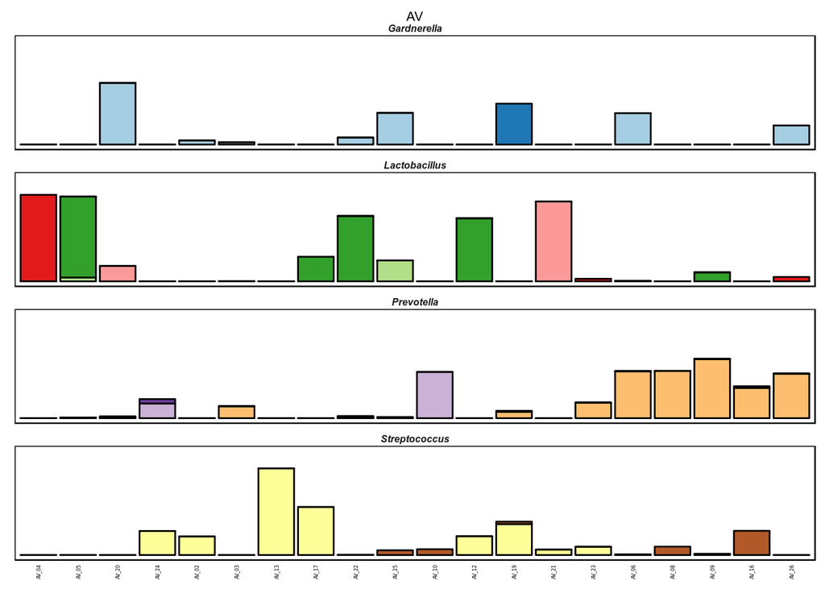

```r
ps_Eline_AV_relabundf_ASV <-ps_Eline_AV_relabundf %>%
  select(-highest_unclassified_rank, - genus) %>%
  left_join(ASV_table) %>%
  mutate(Include = toupper(Include)) %>%
  filter(Include == "YES")

AV_ASV <- ps_Eline_AV_relabundf_ASV %>%
  ggplot(aes(x=Sample, y=Abundance, fill=taxon_name)) +
  geom_bar(stat = "identity", color = "black", position = position_stack(reverse = T)) +
  ylab("Relative abundance (%)") +
  xlab("") +
  theme_pub() +
  theme(axis.text.x= element_text(size = 3,colour="black",angle=90),
        axis.ticks.x=element_blank(),
        axis.text.y = element_blank(),
        axis.ticks.y = element_blank(),
        axis.title = element_blank(),
        legend.position="none",
        legend.text = element_text(size = 8, face = "italic"),
        strip.text.x = element_text(size = 6, face = "bold.italic", margin = margin(t = 0, b = 1)),
        plot.title = element_text(size = 8)) +
  labs(fill="") +
  scale_fill_manual(values = c(colours,"#FF0000","#000000","#FFFFFF")) +
  ylim(0,1.2) +
  guides(fill=guide_legend(byrow=F,
                           ncol=3)) +
  ggtitle("AV") +
  facet_wrap(~genus, nrow = 4)

E_legend <- ggpubr::get_legend(AV_ASV)

AV_ASV <- AV_ASV + theme(legend.position = "none")

AV_ASV
```

And now the BV plots

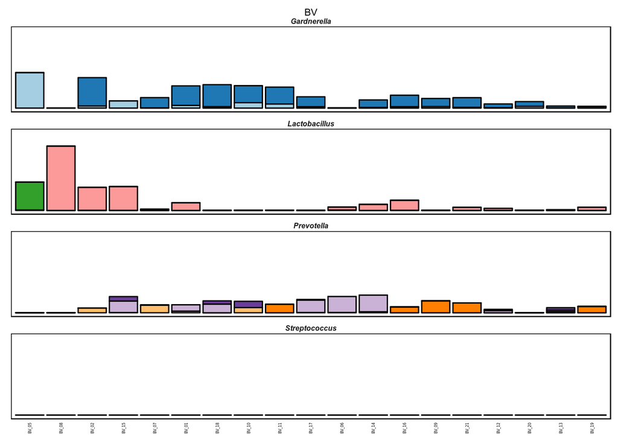

```r
ps_Eline_BV_relabundf_ASV <-ps_Eline_BV_relabundf %>%
  select(-highest_unclassified_rank, - genus) %>%
  left_join(ASV_table) %>%
  mutate(Include = toupper(Include)) %>%
  filter(Include == "YES")

BV_ASV <- ps_Eline_BV_relabundf_ASV %>%
  ggplot(aes(x=Sample, y=Abundance, fill=taxon_name)) +
  geom_bar(stat = "identity", color = "black", position = position_stack(reverse = T)) +
  ylab("Relative abundance (%)") +
  xlab("") +
  theme_pub() +
  theme(axis.text.x= element_text(size = 3,colour="black",angle=90),
        axis.ticks.x=element_blank(),
        axis.text.y = element_blank(),
        axis.ticks.y = element_blank(),
        axis.title = element_blank(),
        legend.position="none",
        legend.text = element_text(size = 2, face = "italic"),
        strip.text.x = element_text(size = 6, face = "bold.italic", margin = margin(t = 0, b = 1)),
        plot.title = element_text(size = 8)) +
  labs(fill="") +
  scale_fill_manual(values = c(colours,"#FF0000","#000000","#FFFFFF")) +
  ylim(0,1.2) +
  guides(fill=guide_legend(byrow=F,
                           ncol=3)) +
  ggtitle("BV") +
  facet_wrap(~genus, nrow = 4)

BV_ASV
```

And finally the NL plots.

```r
ps_Eline_NL_relabundf_ASV <-ps_Eline_NL_relabundf %>%
  select(-highest_unclassified_rank, - genus) %>%
  left_join(ASV_table) %>%
  mutate(Include = toupper(Include)) %>%
  filter(Include == "YES")

NL_ASV <- ps_Eline_NL_relabundf_ASV %>%
  ggplot(aes(x=Sample, y=Abundance, fill=taxon_name)) +
  geom_bar(stat = "identity", color = "black", position = position_stack(reverse = T)) +
  ylab("Relative abundance (%)") +
  xlab("") +
  theme_pub() +
  theme(axis.title.y = element_text(size = 6),
        axis.ticks.y = element_line(size = 0.2),
        axis.text.y = element_text(size = 4, margin = margin(l = 2)),
        axis.text.x= element_text(size = 3,colour="black",angle=90),
        axis.ticks.x=element_blank(),
        legend.position="none",
        legend.text = element_text(size = 4, face = "italic", margin = margin(l = 0)),
        legend.key.size = unit(4, "pt"),
        legend.box.margin = margin(t = -8),
        legend.margin = margin(l = 0),
        strip.text.x = element_text(size = 6, face = "bold.italic", margin = margin(t = 0, b = 1)),
        plot.title = element_text(size = 8)) +
  labs(fill="") +
  scale_fill_manual(values = c(colours,"#FF0000","#000000","#FFFFFF")) +
  ylim(0,1.2) +
  scale_y_continuous(breaks=c(0,0.5,1))+
  guides(fill=guide_legend(byrow=F,
                           ncol=3)) +
  ggtitle("NL") +
  facet_wrap(~genus, nrow = 4)
```

Now, merge all of them together for Figure 3.

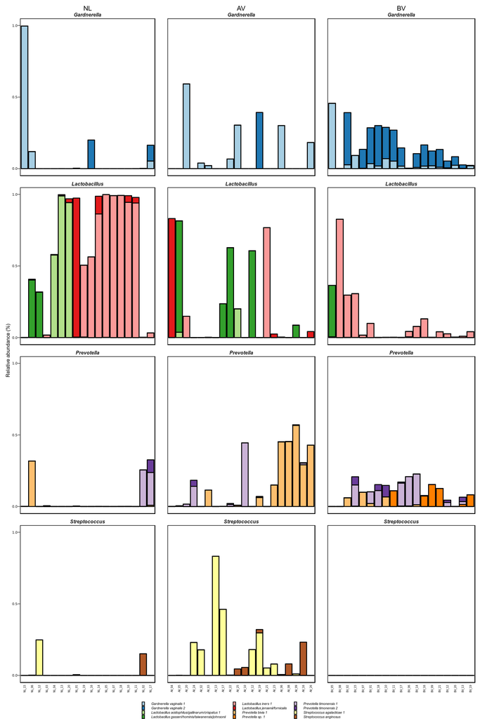

```r
ggarrange(NL_ASV, AV_ASV, BV_ASV,
          ncol = 3,
          align = 'h',
          common.legend = T,
          legend = "bottom")
```

```r
ggsave("Figure3.png", width = 11.3, height = 9.5, units = 'cm')
```

# Additional plots: Heatmap ASV level

## Lactobacillus only

We’re always interested in the Lactobacillus ASVs. Let’s prune these from the dataset and see which ASVs are shared between conditions and which are not.

```r
lactos <- subset_taxa(ps_Eline_relabun, genus=="Lactobacillus")
lactos <- prune_taxa(taxa_sums(lactos) > 0, lactos)
lactos <- prune_samples(sample_sums(lactos) > 0, lactos)
ntaxa(lactos)
```

```
## [1] 17
```

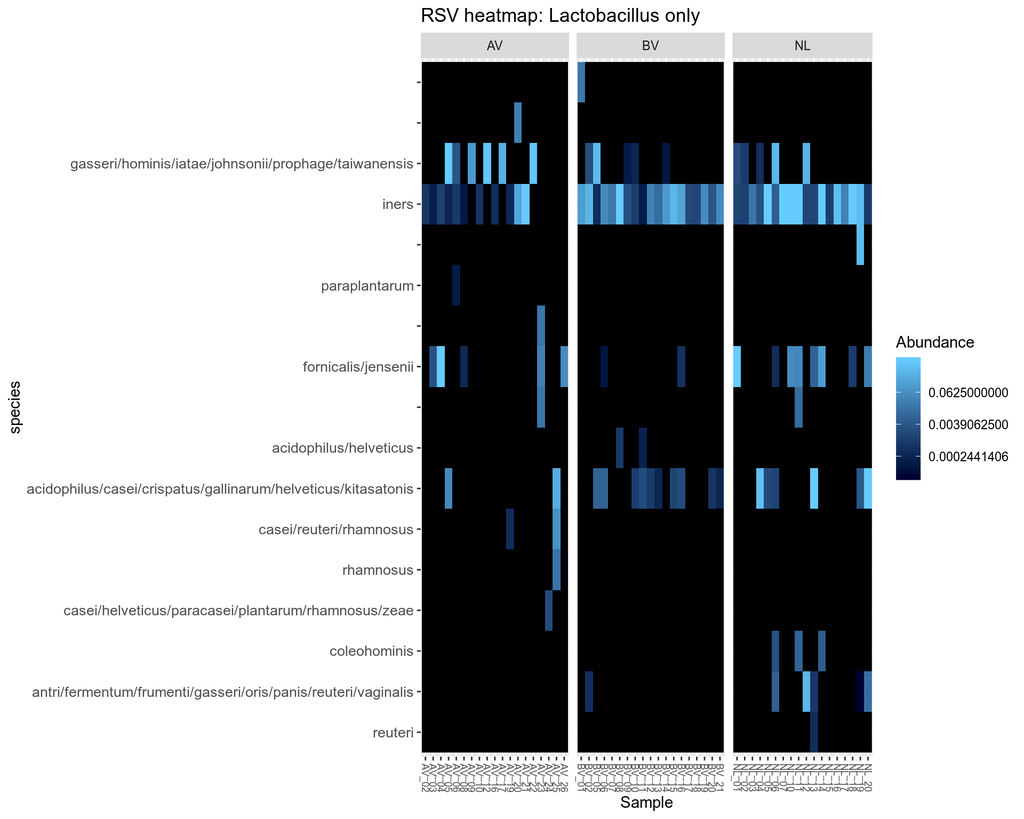

```r
plot_heatmap(lactos,"Type",title="RSV heatmap: Lactobacillus only", taxa.label='species') +
  facet_grid(~condition, scales="free_x", space= "free_x")
```

Samples that don’t have any of these sequences, are dropped. Labels on the left are species names (if classified)

## Gardnerella only

```r
gard <- subset_taxa(ps_Eline_relabun, genus=="Gardnerella")
gard <- prune_taxa(taxa_sums(gard) > 0, gard)
gard <- prune_samples(sample_sums(gard) > 0, gard)
ntaxa(gard)
```

```
## [1] 4
```

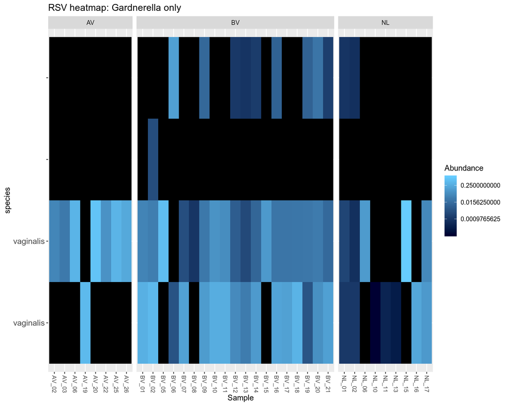

```r
plot_heatmap(gard,"Type",title="RSV heatmap: Gardnerella only", taxa.label='species') + facet_grid(~condition, scales="free_x", space= "free_x")
```

## Prevotella only

```r
gard <- subset_taxa(ps_Eline_relabun, genus=="Prevotella")
gard <- prune_taxa(taxa_sums(gard) > 0, gard)
gard <- prune_samples(sample_sums(gard) > 0, gard)
ntaxa(gard)
```

```
## [1] 26
```

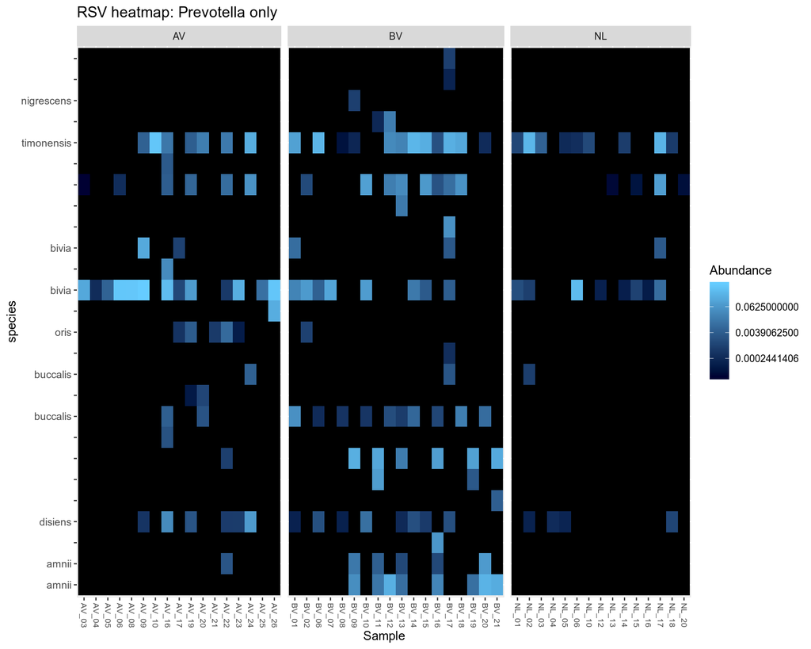

```r
plot_heatmap(gard,"Type",title="RSV heatmap: Prevotella only", taxa.label='species') + facet_grid(~condition, scales="free_x", space= "free_x")
```

# Additional plots: Gram positive vs Negative

We were also interested in whether there was a difference between gram + and gram -. Eline manually identified these based on their genus classification.

```r
gram <- read.csv("gramstain_tabel.csv")
```

## AV Only

Prune AV samples only

```r
samples_to_keep <- sample_data(ps_Eline)$condition=="AV"
ps_Eline_AV  <- prune_samples(samples_to_keep,ps_Eline)
```

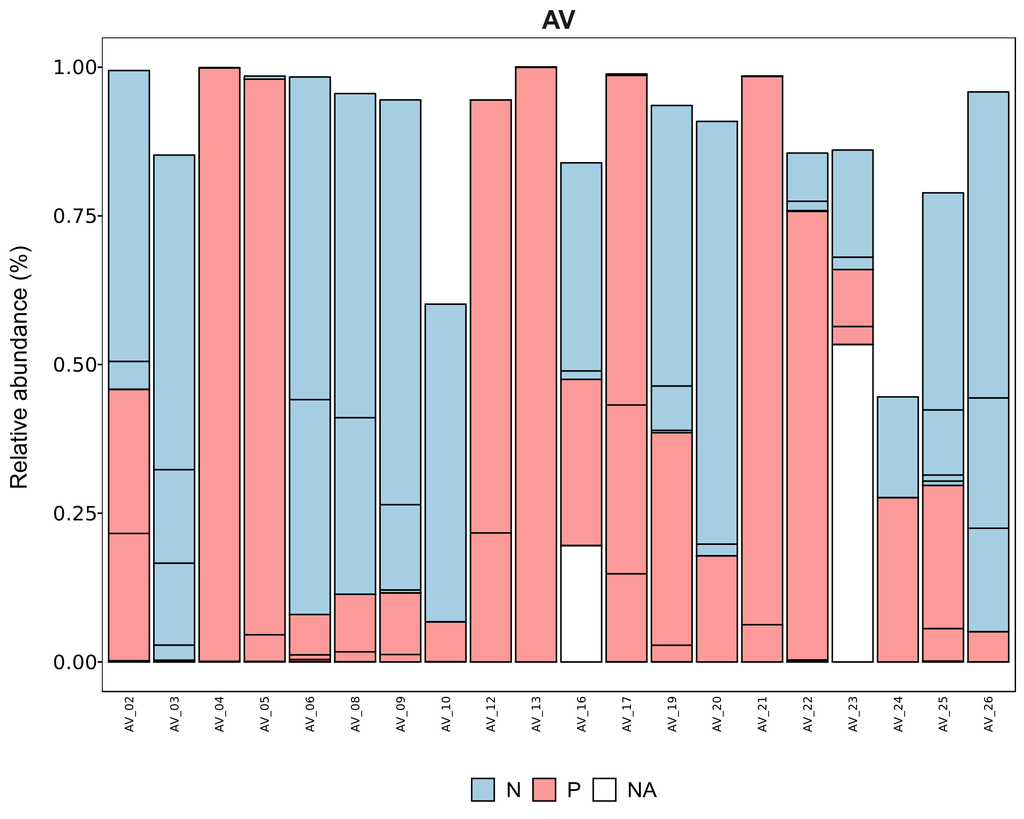

```r
# Taxonomic composition
# Calculate relative abundance
ps_Eline_AV_relabun <- transform_sample_counts(ps_Eline_AV,  function(OTU) OTU/sum(OTU))

# Calculate top 20 OTUs
top20otus = names(sort(taxa_sums(ps_Eline_AV_relabun), TRUE)[1:20])
ps_Eline_AV_relabun_top20 = prune_taxa(top20otus, ps_Eline_AV_relabun)

# Convert phyloseq object into large dataframe to be able to change the order of the stacking
ps_Eline_AV_relabun_top20df <- psmelt(ps_Eline_AV_relabun_top20)

# Add new column with highest unclassified taxonomic rank
highest_unclassified_rank <- name_otus(ps_Eline_AV_relabun_top20)
  # Convert to df
highest_unclassified_rankdf <- cbind(read.table(text=names(highest_unclassified_rank)),highest_unclassified_rank)
  # Merge
ps_Eline_AV_relabun_top20df <- merge(ps_Eline_AV_relabun_top20df,highest_unclassified_rankdf,by.x="OTU",by.y="V1")

# Relevel to get right order in legend
temp <- unique(ps_Eline_AV_relabun_top20df[order(-ps_Eline_AV_relabun_top20df$Abundance),"highest_unclassified_rank"])
ps_Eline_AV_relabun_top20df$highest_unclassified_rank <- factor(ps_Eline_AV_relabun_top20df$highest_unclassified_rank, levels=temp)

# Merge with gram dataset
ps_Eline_AV_relabun_top20df <- merge.data.frame(ps_Eline_AV_relabun_top20df, gram, by="highest_unclassified_rank",all.x = T)

# Plot using ggplot2, colouring genus
ggplot(ps_Eline_AV_relabun_top20df[order(ps_Eline_AV_relabun_top20df$Abundance),], aes(x=Sample, y=Abundance, fill=Gram_stain)) + geom_bar(stat = "identity", color = "black") +
  ylab("Relative abundance (%) \n") +
  xlab("") +
  theme_pub() +
  theme(axis.text.x= element_text(size = 8,colour="black",angle=90),
        axis.ticks.x=element_blank(),
        legend.position="bottom") +
  labs(fill="") +
  scale_fill_manual(values = c(colours[1],colours[5])) +
  ylim(0,1.2) +
  scale_y_continuous(breaks=c(0,0.25,0.5,0.75,1))+
  guides(fill=guide_legend(byrow=F,ncol=3)) +
  facet_wrap(~condition,scales="free_x")
```

## BV Only

Prune BV samples only

```r
samples_to_keep <- sample_data(ps_Eline)$condition=="BV"
ps_Eline_BV  <- prune_samples(samples_to_keep,ps_Eline)
```

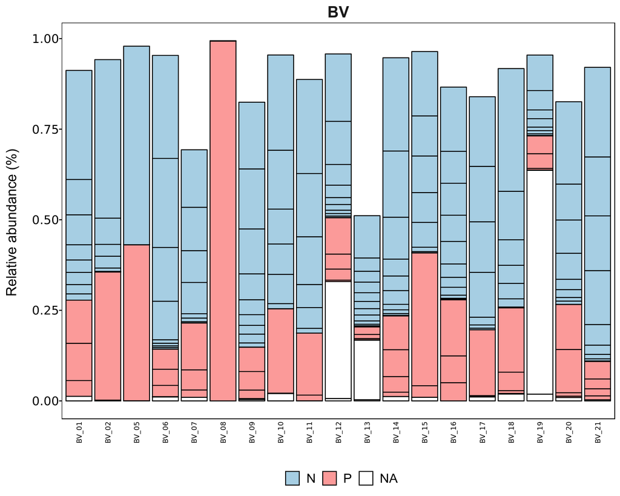

```r
# Taxonomic composition
# Calculate relative abundance
ps_Eline_BV_relabun <- transform_sample_counts(ps_Eline_BV,  function(OTU) OTU/sum(OTU))

# Calculate top 20 OTUs
top20otus = names(sort(taxa_sums(ps_Eline_BV_relabun), TRUE)[1:20])
ps_Eline_BV_relabun_top20 = prune_taxa(top20otus, ps_Eline_BV_relabun)

# Convert phyloseq object into large dataframe to be able to change the order of the stacking
ps_Eline_BV_relabun_top20df <- psmelt(ps_Eline_BV_relabun_top20)

# Add new column with highest unclassified taxonomic rank
highest_unclassified_rank <- name_otus(ps_Eline_BV_relabun_top20)
  # Convert to df
highest_unclassified_rankdf <- cbind(read.table(text=names(highest_unclassified_rank)),highest_unclassified_rank)
  # Merge
ps_Eline_BV_relabun_top20df <- merge(ps_Eline_BV_relabun_top20df,highest_unclassified_rankdf,by.x="OTU",by.y="V1")

# Relevel to get right order in legend
temp <- unique(ps_Eline_BV_relabun_top20df[order(-ps_Eline_BV_relabun_top20df$Abundance),"highest_unclassified_rank"])
ps_Eline_BV_relabun_top20df$highest_unclassified_rank <- factor(ps_Eline_BV_relabun_top20df$highest_unclassified_rank, levels=temp)

# Merge with gram dataset
ps_Eline_BV_relabun_top20df <- merge.data.frame(ps_Eline_BV_relabun_top20df, gram, by="highest_unclassified_rank",all.x = T)

# Plot using ggplot2, colouring genus
ggplot(ps_Eline_BV_relabun_top20df[order(ps_Eline_BV_relabun_top20df$Abundance),], aes(x=Sample, y=Abundance, fill=Gram_stain)) + geom_bar(stat = "identity", color = "black") +
  ylab("Relative abundance (%) \n") +
  xlab("") +
  theme_pub() +
  theme(axis.text.x= element_text(size = 8,colour="black",angle=90),
        axis.ticks.x=element_blank(),
        legend.position="bottom") +
  labs(fill="") +
  scale_fill_manual(values = c(colours[1],colours[5])) +
  ylim(0,1.2) +
  scale_y_continuous(breaks=c(0,0.25,0.5,0.75,1))+
  guides(fill=guide_legend(byrow=F,ncol=3)) +
  facet_wrap(~condition,scales="free_x")
```

## NL Only

Prune NL samples only

```r
samples_to_keep <- sample_data(ps_Eline)$condition=="NL"
ps_Eline_NL  <- prune_samples(samples_to_keep,ps_Eline)
```

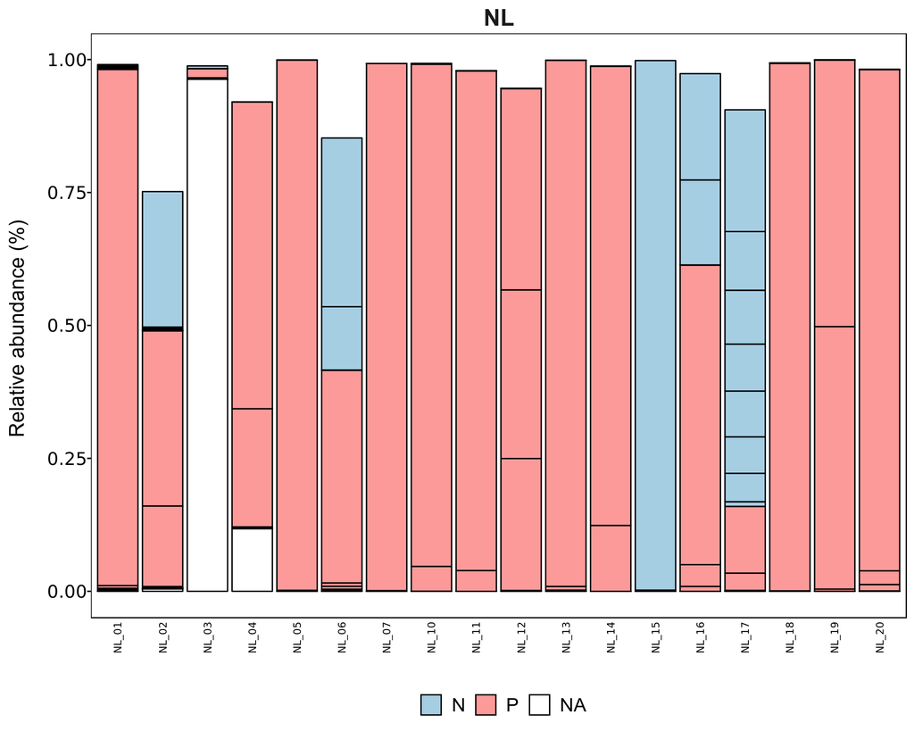

```r
# Taxonomic composition
# Calculate relative abundance
ps_Eline_NL_relabun <- transform_sample_counts(ps_Eline_NL,  function(OTU) OTU/sum(OTU))

# Calculate top 20 OTUs
top20otus = names(sort(taxa_sums(ps_Eline_NL_relabun), TRUE)[1:20])
ps_Eline_NL_relabun_top20 = prune_taxa(top20otus, ps_Eline_NL_relabun)

# Convert phyloseq object into large dataframe to be able to change the order of the stacking
ps_Eline_NL_relabun_top20df <- psmelt(ps_Eline_NL_relabun_top20)

# Add new column with highest unclassified taxonomic rank
highest_unclassified_rank <- name_otus(ps_Eline_NL_relabun_top20)
  # Convert to df
highest_unclassified_rankdf <- cbind(read.table(text=names(highest_unclassified_rank)),highest_unclassified_rank)
  # Merge
ps_Eline_NL_relabun_top20df <- merge(ps_Eline_NL_relabun_top20df,highest_unclassified_rankdf,by.x="OTU",by.y="V1")

# Relevel to get right order in legend
temp <- unique(ps_Eline_NL_relabun_top20df[order(-ps_Eline_NL_relabun_top20df$Abundance),"highest_unclassified_rank"])
ps_Eline_NL_relabun_top20df$highest_unclassified_rank <- factor(ps_Eline_NL_relabun_top20df$highest_unclassified_rank, levels=temp)

# Merge with gram dataset
ps_Eline_NL_relabun_top20df <- merge.data.frame(ps_Eline_NL_relabun_top20df, gram, by="highest_unclassified_rank",all.x = T)

# Plot using ggplot2, colouring genus
ggplot(ps_Eline_NL_relabun_top20df[order(ps_Eline_NL_relabun_top20df$Abundance),], aes(x=Sample, y=Abundance, fill=Gram_stain)) + geom_bar(stat = "identity", color = "black") +
  ylab("Relative abundance (%) \n") +
  xlab("") +
  theme_pub() +
  theme(axis.text.x= element_text(size = 8,colour="black",angle=90),
        axis.ticks.x=element_blank(),
        legend.position="bottom") +
  labs(fill="") +
  scale_fill_manual(values = c(colours[1],colours[5])) +
  ylim(0,1.2) +
  scale_y_continuous(breaks=c(0,0.25,0.5,0.75,1))+
  guides(fill=guide_legend(byrow=F,ncol=3)) +
  facet_wrap(~condition,scales="free_x")
```